# BayesianProbability-BostonHousing

Nikhil Kamath

2024-07-31

## Introduction and Background

### Bayesian Ridge Regression

**Bayesian Ridge Regression** is a Bayesian approach to linear regression that incorporates prior distributions on the regression coefficients and the variance of the error term. The model assumes that the regression coefficients follow a Gaussian prior with zero mean and a fixed variance. This approach regularizes the regression by shrinking the coefficients towards zero, which helps to mitigate overfitting. The Bayesian Ridge model estimates both the regression coefficients and their uncertainty, providing a probabilistic interpretation of the predictions.

Key aspects: - **Prior Distribution**: Coefficients are assumed to follow a Gaussian distribution with zero mean. - **Hyperparameters**: Include the variance of the prior distribution and the variance of the noise. - **Inference**: Uses Bayesian inference to update beliefs about the coefficients based on observed data.

### Bayesian Lasso

**Bayesian Lasso** extends the concept of Lasso (Least Absolute Shrinkage and Selection Operator) regression by adopting a Bayesian framework. Unlike the Ridge regression which uses a Gaussian prior, the Bayesian Lasso applies a Laplace prior (also known as a double-exponential prior) on the coefficients. This prior encourages sparsity, meaning that it can shrink some coefficients to exactly zero, effectively performing feature selection.

Key aspects: - **Prior Distribution**: Coefficients are assumed to follow a Laplace distribution, promoting sparsity. - **Hyperparameters**: Include the scale parameter of the Laplace distribution and the variance of the noise. - **Inference**: Bayesian Lasso provides a probabilistic approach to feature selection and coefficient estimation.

### Bayesian Stochastic Search Variable Selection (SSVS)

**Bayesian Stochastic Search Variable Selection (SSVS)** is a Bayesian approach to variable selection that combines a stochastic search algorithm with Bayesian inference. In SSVS, each variable is assigned a binary inclusion indicator that determines whether it is included in the model or not. The model then uses a stochastic search process to explore different subsets of variables and estimate the posterior probabilities of these variables being included.

Key aspects: - **Prior Distribution**: Uses a mixture of normal distributions to allow for both inclusion and exclusion of variables. - **Binary Inclusion Indicators**: Each predictor is associated with a binary variable indicating its inclusion. - **Inference**: Involves a Markov Chain Monte Carlo (MCMC) process to sample from the posterior distribution and estimate the inclusion probabilities.

### Overview of the Boston Housing Dataset

The **Boston Housing Dataset** is a well-known dataset used for evaluating regression models. It contains information about housing values in suburbs of Boston and is often used to study and practice various statistical and machine learning techniques. The dataset includes the following features:

- **crim**: Per capita crime rate by town.
- **zn**: Proportion of residential land zoned for lots over 25,000 sq. ft.
- **indus**: Proportion of non-retail business acres per town.
- **chas**: Charles River dummy variable (1 if tract bounds river; 0 otherwise).
- **nox**: Nitric oxides concentration (parts per 10 million).
- **rm**: Average number of rooms per dwelling.
- **age**: Proportion of owner-occupied units built prior to 1940.
- **dis**: Weighted distances to five Boston employment centers.
- **rad**: Index of accessibility to radial highways.
- **tax**: Full-value property tax rate per $10,000.
- **ptratio**: Pupil-teacher ratio by town.
- **b**: $1000(Bk - 0.63)^2$ where Bk is the proportion of Black residents by town.
- **lstat**: Percentage of lower status of the population.
- **medv**: Median value of owner-occupied homes in $1000s (target variable).

Each row in the dataset represents a different suburb of Boston, and the goal is often to predict the `medv` (median value of homes) based on the other features. This dataset provides a rich context for exploring and comparing different regression models, especially those that incorporate Bayesian methods.

### Loading Libraries

```r
install.packages("loo")
library(loo)
install.packages("dplyr")
library(dplyr)
install.packages("MASS")
library(MASS)
install.packages("caret")
library(caret)
```

```r
install.packages("ggplot2")
library(ggplot2)

install.packages("reshape2")
library(reshape2)

install.packages("mvtnorm")
library(mvtnorm)

install.packages("loo")
library(loo)

install.packages("caret")
library(caret)  # For createFolds
```

### Simple Data Analysis

```r
data(Boston)

head(Boston)
```

```
##      crim zn indus chas   nox    rm  age    dis rad tax ptratio  black lstat
## 1 0.00632 18  2.31    0 0.538 6.575 65.2 4.0900   1 296    15.3 396.90  4.98
## 2 0.02731  0  7.07    0 0.469 6.421 78.9 4.9671   2 242    17.8 396.90  9.14
## 3 0.02729  0  7.07    0 0.469 7.185 61.1 4.9671   2 242    17.8 392.83  4.03
## 4 0.03237  0  2.18    0 0.458 6.998 45.8 6.0622   3 222    18.7 394.63  2.94
## 5 0.06905  0  2.18    0 0.458 7.147 54.2 6.0622   3 222    18.7 396.90  5.33
## 6 0.02985  0  2.18    0 0.458 6.430 58.7 6.0622   3 222    18.7 394.12  5.21
##   medv
## 1 24.0
## 2 21.6
## 3 34.7
## 4 33.4
## 5 36.2
## 6 28.7
```

```r
summary(Boston)
```

```
##       crim                zn             indus            chas
##  Min.   : 0.00632   Min.   :  0.00   Min.   : 0.46   Min.   :0.00000
##  1st Qu.: 0.08205   1st Qu.:  0.00   1st Qu.: 5.19   1st Qu.:0.00000
##  Median : 0.25651   Median :  0.00   Median : 9.69   Median :0.00000
##  Mean   : 3.61352   Mean   : 11.36   Mean   :11.14   Mean   :0.06917
##  3rd Qu.: 3.67708   3rd Qu.: 12.50   3rd Qu.:18.10   3rd Qu.:0.00000
##  Max.   :88.97620   Max.   :100.00   Max.   :27.74   Max.   :1.00000
##       nox               rm             age              dis
##  Min.   :0.3850   Min.   :3.561   Min.   :  2.90   Min.   : 1.130
##  1st Qu.:0.4490   1st Qu.:5.886   1st Qu.: 45.02   1st Qu.: 2.100
##  Median :0.5380   Median :6.208   Median : 77.50   Median : 3.207
##  Mean   :0.5547   Mean   :6.285   Mean   : 68.57   Mean   : 3.795
##  3rd Qu.:0.6240   3rd Qu.:6.623   3rd Qu.: 94.08   3rd Qu.: 5.188
##  Max.   :0.8710   Max.   :8.780   Max.   :100.00   Max.   :12.127
##       rad              tax           ptratio          black
##  Min.   : 1.000   Min.   :187.0   Min.   :12.60   Min.   :  0.32
##  1st Qu.: 4.000   1st Qu.:279.0   1st Qu.:17.40   1st Qu.:375.38
##  Median : 5.000   Median :330.0   Median :19.05   Median :391.44
##  Mean   : 9.549   Mean   :408.2   Mean   :18.46   Mean   :356.67
##  3rd Qu.:24.000   3rd Qu.:666.0   3rd Qu.:20.20   3rd Qu.:396.23
##  Max.   :24.000   Max.   :711.0   Max.   :22.00   Max.   :396.90
##      lstat            medv
##  Min.   : 1.73   Min.   : 5.00
##  1st Qu.: 6.95   1st Qu.:17.02
##  Median :11.36   Median :21.20
##  Mean   :12.65   Mean   :22.53
##  3rd Qu.:16.95   3rd Qu.:25.00
##  Max.   :37.97   Max.   :50.00
```

### Data Preprocessing…

```r
# Preprocess data to keep only numerical columns
boston_numeric <- Boston %>% select_if(is.numeric)

# Check for high correlations and remove highly correlated predictors
corr_matrix <- cor(boston_numeric)
high_corr <- findCorrelation(corr_matrix, cutoff = 0.5)
boston_reduced <- boston_numeric[, -high_corr]

# Ensure medv (median value of owner-occupied homes) is included
boston_reduced$medv <- Boston$medv
y_boston <- boston_reduced$medv
X_boston <- model.matrix(medv ~ . - 1, data = boston_reduced)

# Get the number of observations and predictors
n <- length(y_boston)
p <- ncol(X_boston)
```

### Correlation Heatmap

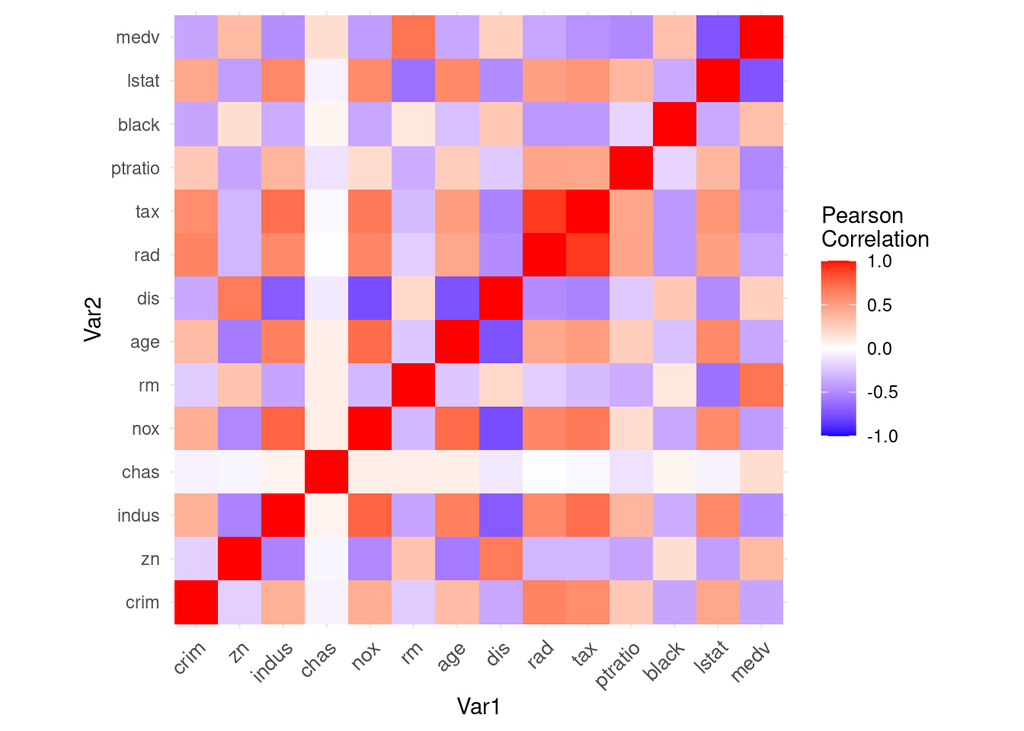

```r
# Melt correlation matrix for ggplot2
melted_corr <- melt(corr_matrix)

# Plot heatmap
ggplot(data = melted_corr, aes(x = Var1, y = Var2, fill = value)) +
  geom_tile() +
  scale_fill_gradient2(low = "blue", high = "red", mid = "white", midpoint = 0, limit = c(-1, 1), space = "Lab", name="Pearson\nCorrelation") +
  theme_minimal() +
  theme(axis.text.x = element_text(angle = 45, vjust = 1, size = 10, hjust = 1)) +
  coord_fixed()
```

### Splitting the boston housing data into training and test split using a 70-30 test class:

```r
X<- X_boston
Y<- y_boston

training_split <- sample(1:nrow(X), size = 0.7 * nrow(X))
X_train <- X[training_split, ]
Y_train <- Y[training_split]
X_Test <- X[-training_split, ]
Y_Test <- Y[-training_split]

n <- length(Y_train)
p <- ncol(X_train)
```

## Bayesian Ridge Regression

### Bayesian Ridge Regression is a method that incorporates prior distributions on both regression coefficients and the error variance. By assuming that the coefficients follow a Gaussian prior with zero mean and a fixed variance, this approach regularizes the model by shrinking coefficients towards zero, thus reducing overfitting. The model estimates both the coefficients and their uncertainty, offering a probabilistic view of the predictions.

```r
bayesian_ridge <- function(X, y, n_iter = 1000, sigma2 = 1, tau2 = 2) {
  XtX <- t(X) %*% X
  Xty <- t(X) %*% y
  beta_samples <- matrix(0, ncol = ncol(X), nrow = n_iter)

  for (i in 1:n_iter) {
    Sigma_inv <- XtX + diag(ncol(X)) / tau2
    Sigma <- solve(Sigma_inv)
    mu <- Sigma %*% Xty / sigma2
    beta_samples[i, ] <- rmvnorm(1, mean = mu, sigma = Sigma)
  }

  colnames(beta_samples) <- colnames(X)
  return(beta_samples)
}
```

## Bayesian Lasso

### Bayesian Lasso is a regularization technique that applies a Laplace prior to the regression coefficients. This method encourages sparsity in the model by shrinking some coefficients exactly to zero, effectively performing variable selection. By incorporating a probabilistic approach, Bayesian Lasso estimates both the coefficients and their uncertainty, providing a robust framework for handling high-dimensional data.

```r
bayesian_lasso <- function(X, y, n_iter = 1000, sigma2 = 1, lambda = 1, epsilon = 1e-6) {
  p <- ncol(X)
  XtX <- t(X) %*% X
  Xty <- t(X) %*% y
  beta_samples <- matrix(0, ncol = p, nrow = n_iter)
  tau_samples <- matrix(0, ncol = p, nrow = n_iter)
  tau2 <- rep(1, p)

  for (i in 1:n_iter) {
    # Sample betas
    Sigma_inv <- XtX + diag(1 / tau2 + epsilon)
    Sigma <- solve(Sigma_inv)
    mu <- Sigma %*% Xty / sigma2
    beta_samples[i, ] <- rmvnorm(1, mean = mu, sigma = Sigma)

    # Sample tau2
    for (j in 1:p) {
      beta_j <- beta_samples[i, j]
      tau_samples[i, j] <- 1 / rgamma(1, shape = 1, rate = abs(beta_j) / lambda)
    }
    tau2 <- tau_samples[i, ]
  }

  colnames(beta_samples) <- colnames(X)
  return(beta_samples)
}
```

### Finding the best lambda value in the Bayesian Lasso regression…

```r
find_best_lambda_lasso <- function(X, y) {
  lambdas <- seq(0.1, 2, by = 0.1)

  rmse_ridge <- sapply(lambdas, function(lambda) {
    samples <- bayesian_lasso(X, y, lambda = lambda)
    beta <- colMeans(samples)
    sqrt(mean((y - X %*% beta)^2))
  })

  best_lambda_ridge <- lambdas[which.min(rmse_ridge)]
  return(best_lambda_ridge)
}

find_best_lambda_ridge <- function(X, y) {
  lambdas <- seq(0.1, 2, by = 0.1)

  rmse_ridge <- sapply(lambdas, function(lambda) {
    samples <- bayesian_ridge(X, y, tau2 = lambda)
    beta <- colMeans(samples)
    sqrt(mean((y - X %*% beta)^2))
  })

  best_lambda_ridge <- lambdas[which.min(rmse_ridge)]
  return(best_lambda_ridge)
}
```

### Finding the best lambda value using the Bayesian Ridge Regression…

```r
best_lambda_ridge <- find_best_lambda_ridge(X, Y)
print(best_lambda_ridge)
```

```
## [1] 2
```

```r
best_lambda_lasso <- find_best_lambda_lasso(X,Y)
print(best_lambda_lasso)
```

```
## [1] 0.1
```

### Applying the best lambda values to the equation at hand….

```r
# Fit Bayesian Lasso model using the best lambda

# Function to calculate DIC
calculate_dic <- function(log_posterior, pD) {
  deviance <- -2 * log_posterior
  dic <- deviance + 2 * pD
  return(dic)
}

# Function to calculate WAIC
calculate_waic_manual <- function(log_likelihoods) {
  lppd <- sum(log(colMeans(exp(log_likelihoods))))
  p_waic <- sum(apply(log_likelihoods, 2, var))
  waic <- -2 * (lppd - p_waic)
  return(list(waic = waic, lppd = lppd, p_waic = p_waic))
}

lasso_samples <- bayesian_lasso(X, Y, lambda = best_lambda_lasso)
beta_lasso <- colMeans(lasso_samples)
lasso_cred_int <- apply(lasso_samples, 2, quantile, probs = c(0.025, 0.975))
print(beta_lasso)
```

```
##        crim          zn        chas          rm     ptratio       black
## -0.14368324  0.01932045  3.02410472  6.33068321 -1.19829941  0.01400405
```

```r
# Fit Bayesian Ridge model using the best lambda
ridge_samples <- bayesian_ridge(X, Y, tau2 = best_lambda_ridge)
beta_ridge <- colMeans(ridge_samples)
ridge_cred_int <- apply(ridge_samples, 2, quantile, probs = c(0.025, 0.975))
print(beta_ridge)
```

```
##        crim          zn        chas          rm     ptratio       black
## -0.14360840  0.01939370  2.97907586  6.32576667 -1.19704673  0.01403364
```

### Printing lasso and ridge cred. int

```r
print(lasso_cred_int)
```

```
##             crim         zn     chas       rm   ptratio      black
## 2.5%  -0.1545764 0.01518182 2.648285 6.245343 -1.228011 0.01298330
## 97.5% -0.1321791 0.02334744 3.369451 6.424303 -1.168450 0.01495633
```

```r
print(ridge_cred_int)
```

```
##             crim         zn     chas       rm   ptratio      black
## 2.5%  -0.1548667 0.01524809 2.632681 6.229697 -1.230155 0.01303728
## 97.5% -0.1327381 0.02346678 3.300703 6.424790 -1.165283 0.01503183
```

### Stochastic Search Variable function

### Bayesian Stochastic Search Variable Selection (SSVS) is a Bayesian method for selecting variables that integrates a stochastic search with Bayesian inference. It employs binary inclusion indicators for each variable and uses a stochastic search process to explore variable subsets, estimating posterior inclusion probabilities through a Markov Chain Monte Carlo (MCMC) process. Key features include a mixture of normal distributions for prior specification and MCMC for inference.

```r
ssvs_continuous <- function(data, y, x, inprob = 0.9, runs = 10000, burn = 2000, a1 = 1, b1 = 1, prec.beta = 1e-6, progress = FALSE) {
  y <- data[[y]]
  x <- as.matrix(data[x])

  # Error message for missing values
  if (sum(is.na(x)) + sum(is.na(y)) > 0) {
    stop("Missing values in selection")
  }

  # Added scaling inside function for X only
  x <- scale(x)

  p <- ncol(x)
  xp <- matrix(0, 25, p)
  xp[, 1] <- seq(-3, 3, length = 25)
  n <- length(y)
  np <- nrow(xp)

  # Initial values:
  int <- mean(y)
  beta <- rep(0, p)
  alpha <- rep(0, p)
  delta <- rep(0, p)
  taue <- 1 / var(y)

  # Keep track of stuff:
  keep.beta <- matrix(0, runs, p)
  colnames(keep.beta) <- colnames(x)
  keep.int <- keep.taue <- rep(0, runs)
  keep.yp <- matrix(0, runs, np)

  # LET'S ROLL:
  for (i in 1:runs) {
    # Sample taue with check for numerical stability
    taue <- rgamma(1, n / 2 + a1, rate = max(sum((y - int - x %*% beta)^2) / 2 + b1, 1e-10))
    if (is.na(taue)) taue <- 1e-10  # If taue is NA, set to a small value

    # Sample int with check for numerical stability
    int <- rnorm(1, mean(y - x %*% beta), sd = max(1 / sqrt(n * taue + 0.1), 1e-10))

    # Update alpha
    z <- x %*% diag(delta)
    V <- try(solve(taue * t(z) %*% z + prec.beta * diag(p)), silent = TRUE)
    if (inherits(V, "try-error")) {
      V <- diag(p) * 1e-6  # Add small value for numerical stability
    }
    M <- taue * t(z) %*% (y - int)
    alpha <- V %*% M + t(chol(V)) %*% rnorm(p)
    beta <- alpha *

 delta

    # Update inclusion indicators:
    r <- y - int - x %*% beta
    for (j in 1:p) {
      r <- r + x[, j] * beta[j]
      log.p.in <- log(inprob) - 0.5 * taue * sum((r - x[, j] * alpha[j])^2)
      log.p.out <- log(1 - inprob) - 0.5 * taue * sum(r^2)
      diff <- log.p.in - log.p.out
      diff <- ifelse(diff > 10, 10, diff)
      p.in <- exp(diff) / (1 + exp(diff))
      delta[j] <- rbinom(1, 1, p.in)
      beta[j] <- delta[j] * alpha[j]
      r <- r - x[, j] * beta[j]
    }

    # Make predictions:
    yp <- rnorm(np, int + xp %*% beta, 1 / sqrt(taue))

    # Store the output:
    keep.beta[i, ] <- beta
    keep.int[i] <- int
    keep.taue[i] <- taue
    keep.yp[i, ] <- yp

    if ((i %% 1000 == 0) & (progress == TRUE)) {
      plot(beta, main = paste("Iteration", i))
      abline(0, 0)
    }
  }

  result <- list(
    beta = keep.beta[burn:runs, ],
    int = keep.int[burn:runs],
    taue = keep.taue[burn:runs],
    pred = keep.yp[burn:runs, ]
  )

  result
}

ssvs_results_boston <- ssvs_continuous(boston_reduced, y = "medv", x = colnames(X_boston), runs = 1000, burn = 500, a1 = 1, b1 = 1, prec.beta = 1e-6, progress = FALSE)
ssvs_samples_boston <- ssvs_results_boston$beta
ssvs_inclusion_prob_boston <- colMeans(ssvs_samples_boston != 0)
beta_ssvs_boston <- colMeans(ssvs_samples_boston)
print(beta_ssvs_boston)
```

```
##       crim         zn       chas         rm    ptratio      black
## -1.9203733  0.1743323  0.0000000  3.8520504 -2.6715728  0.0000000
```

```r
print(ssvs_inclusion_prob_boston)
```

```
##      crim        zn      chas        rm   ptratio     black
## 1.0000000 0.1736527 0.0000000 0.7445110 1.0000000 0.0000000
```

### Lets see the selcted variables for Ridge, Lasso, and SSVS…

```r
selected_variables_ridge_boston <- which(apply(ridge_cred_int, 2, function(x) sign(x[1]) == sign(x[2])))
selected_variables_lasso_boston <- which(apply(lasso_cred_int, 2, function(x) sign(x[1]) == sign(x[2])))
selected_variables_ssvs_boston <- which(ssvs_inclusion_prob_boston > 0.5)


print(selected_variables_ridge_boston)
```

```
##    crim      zn    chas      rm ptratio   black
##       1       2       3       4       5       6
```

```r
print(selected_variables_lasso_boston)
```

```
##    crim      zn    chas      rm ptratio   black
##       1       2       3       4       5       6
```

```r
print(selected_variables_ssvs_boston)
```

```
##    crim      rm ptratio
##       1       4       5
```

### Next, lets plot the histograms and the traceplots of each graph….

```r
plot_histograms <- function(model_type, selected_variables, samples, X) {
  # Check that the model_type is valid
  if (!model_type %in% c("ridge", "lasso", "ssvs")) {
    stop("Invalid model type. Choose 'ridge', 'lasso', or 'ssvs'.")
  }

  # Check if there are selected variables to plot
  if (length(selected_variables) > 0) {
    par(mfrow = c(2, 2))
    for (i in selected_variables) {
      # Set appropriate title and sample data based on the model type
      if (model_type == "ridge") {
        hist(samples[, i], main = paste("Histogram of Beta (Bayesian Ridge)", colnames(X)[i]), xlab = colnames(X)[i], breaks = 100)
      } else if (model_type == "lasso") {
        hist(samples[, i], main = paste("Histogram of Beta (Bayesian Lasso)", colnames(X)[i]), xlab = colnames(X)[i], breaks = 100)
      } else if (model_type == "ssvs") {
        hist(samples[, i], main = paste("Histogram of Beta (SSVS)", colnames(X)[i]), xlab = colnames(X)[i], breaks = 100)
      }
    }
    par(mfrow = c(1, 1)) # Reset to default layout
  }
}
```

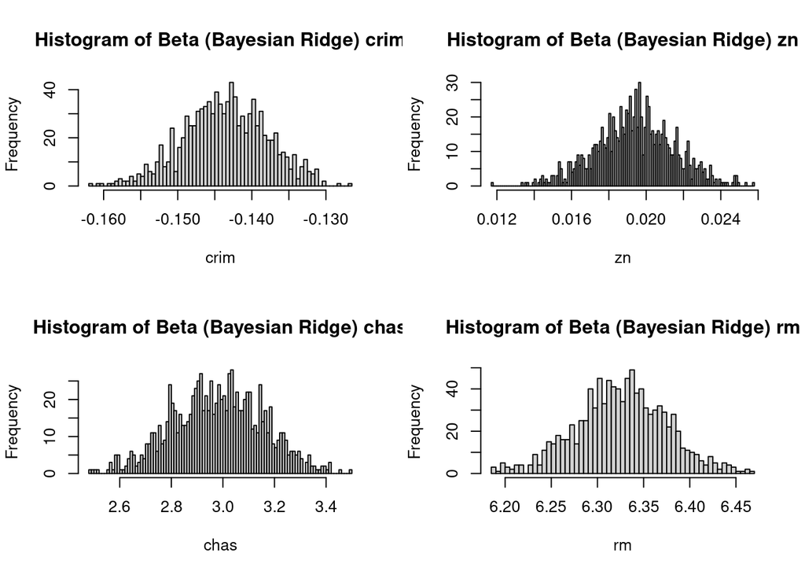

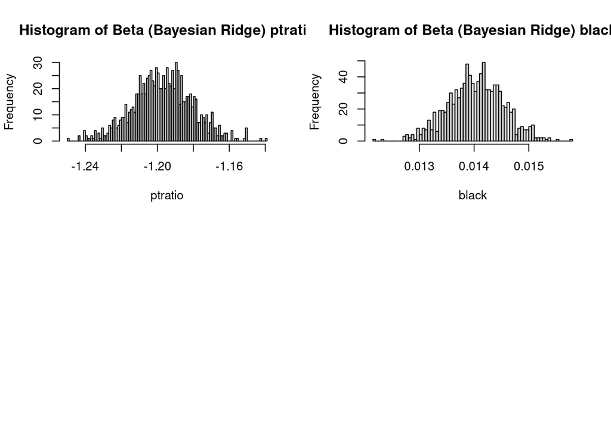

```r
# Example usage
plot_histograms("ridge", selected_variables_ridge_boston, ridge_samples, X_boston)
```

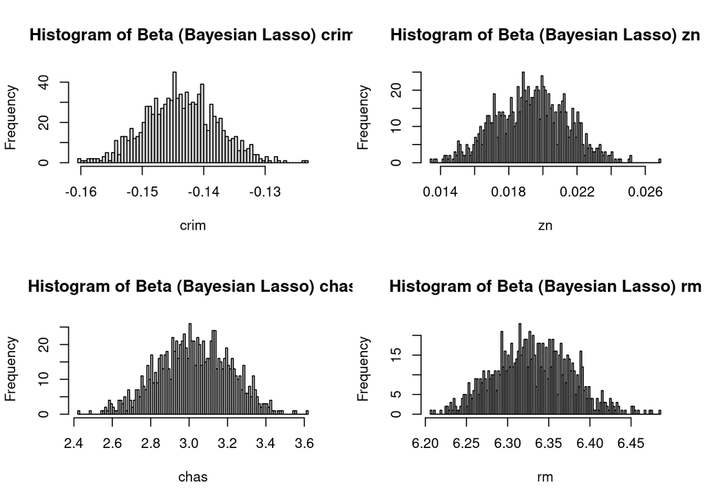

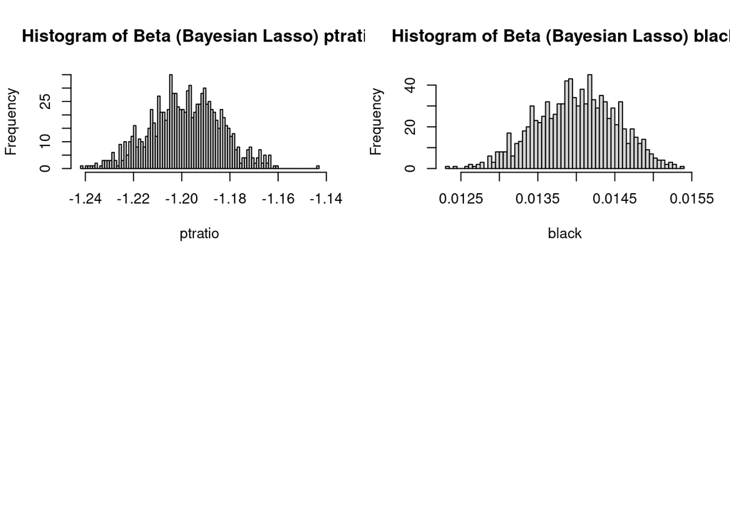

```r
plot_histograms("lasso", selected_variables_lasso_boston, lasso_samples, X_boston)
```

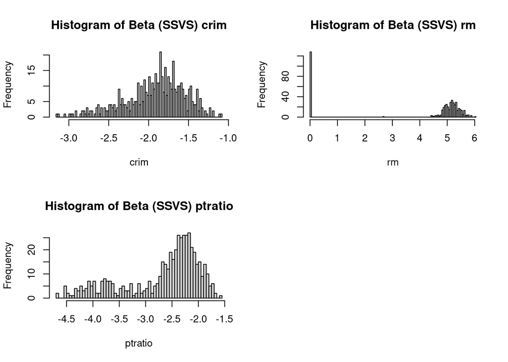

```r
plot_histograms("ssvs", selected_variables_ssvs_boston, ssvs_samples_boston, X_boston)
```

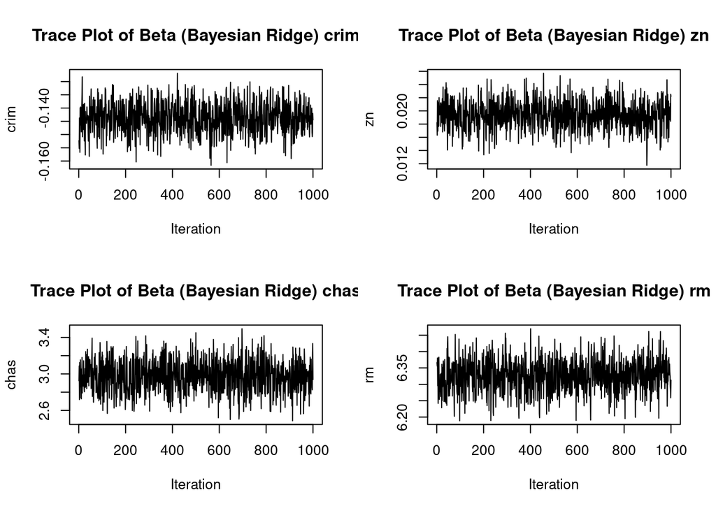

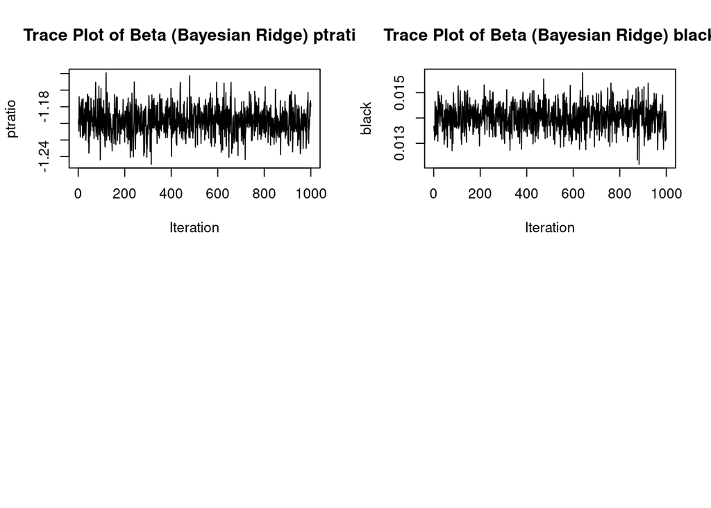

```r
traceplot_bayesian <- function(model_type, selected_variables, samples, X) {
  # Check that the model_type is valid
  if (!model_type %in% c("ridge", "lasso", "ssvs")) {
    stop("Invalid model type. Choose 'ridge', 'lasso', or 'ssvs'.")
  }

  # Check if there are selected variables to plot
  if (length(selected_variables) > 0) {
    par(mfrow = c(2, 2))
    for (i in selected_variables) {
      # Set appropriate title and sample data based on the model type
      if (model_type == "ridge") {
        plot(samples[, i], type = "l", main = paste("Trace Plot of Beta (Bayesian Ridge)", colnames(X)[i]), xlab = "Iteration", ylab = colnames(X)[i])
      } else if (model_type == "lasso") {
        plot(samples[, i], type = "l", main = paste("Trace Plot of Beta (Bayesian Lasso)", colnames(X)[i]), xlab = "Iteration", ylab = colnames(X)[i])
      } else if (model_type == "ssvs") {
        plot(samples[, i], type = "l", main = paste("Trace Plot of Beta (SSVS)", colnames(X)[i]), xlab = "Iteration", ylab = colnames(X)[i])
      }
    }
    par(mfrow = c(1, 1)) # Reset to default layout
  }
}

# Example usage
traceplot_bayesian("ridge", selected_variables_ridge_boston, ridge_samples, X_boston)
```

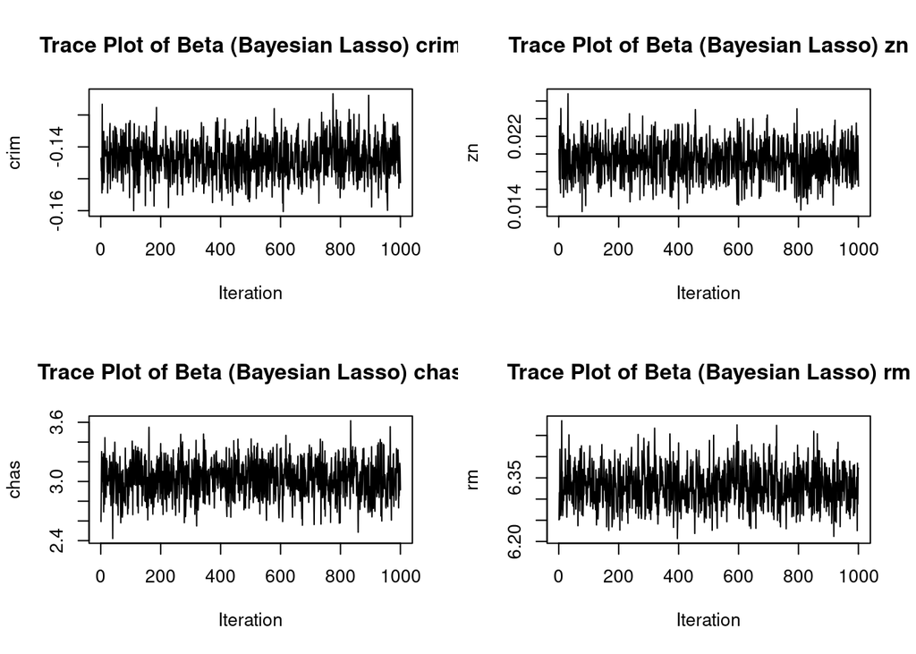

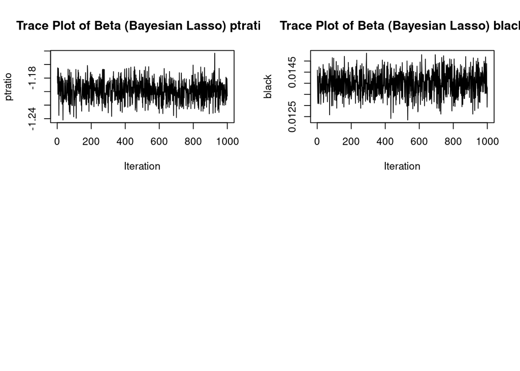

```r
traceplot_bayesian("lasso", selected_variables_lasso_boston, lasso_samples, X_boston)
```

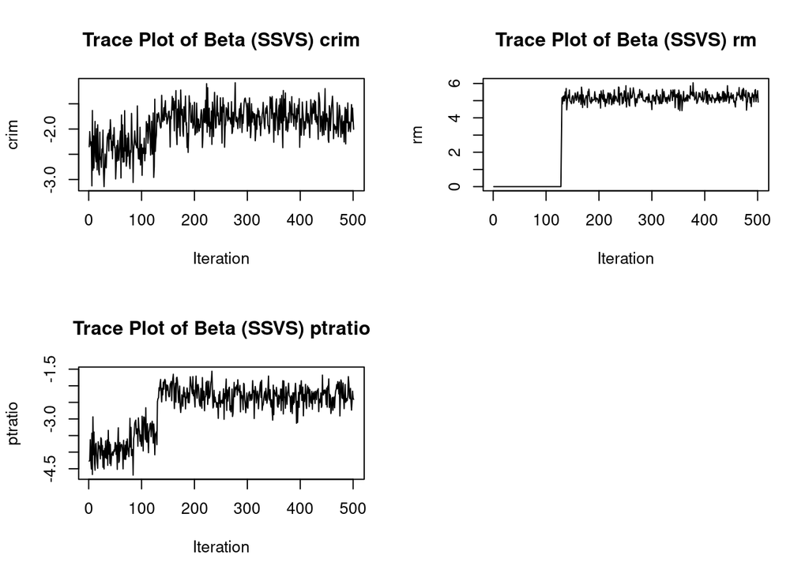

```r
traceplot_bayesian("ssvs", selected_variables_ssvs_boston, ssvs_samples_boston, X_boston)
```

### Next, we are computing the DIC and WAIC and using a log transformation to intepret their results…

```r
compute_dic_waic <- function(samples, X, y) {
  log_lik <- function(beta, X, y) {
    mu <- X %*% beta
    dnorm(y, mu, sd = sd(y), log = TRUE)
  }

  # Compute log-likelihood values
  log_lik_values <- t(apply(samples, 1, function(beta) log_lik(beta, X, y)))

  # Compute DIC
  log_lik_mean <- rowMeans(log_lik_values)
  pD <- mean(apply(log_lik_values, 1, var))  # Variance of log-likelihood values across rows
  DIC <- -2 * mean(log_lik_mean) + 2 * pD

  # Compute WAIC
  waic_res <- loo::waic(log_lik_values)

  list(DIC = DIC, WAIC = waic_res)
}

dic_waic_ridge <- compute_dic_waic(ridge_samples, X, Y)
dic_waic_lasso <- compute_dic_waic(lasso_samples, X, Y)
dic_waic_ssvs <- compute_dic_waic(ssvs_samples_boston, X, Y)
dic_waic_ridge
```

```
## $DIC
## [1] 7.420287
##
## $WAIC
##
## Computed from 1000 by 506 log-likelihood matrix.
##
##           Estimate   SE
## elpd_waic  -1683.3 13.9
## p_waic         0.0  0.0
## waic        3366.6 27.9
```

```r
dic_waic_lasso
```

```
## $DIC
## [1] 7.419996
##
## $WAIC
##
## Computed from 1000 by 506 log-likelihood matrix.
##
##           Estimate   SE
## elpd_waic  -1683.3 13.9
## p_waic         0.0  0.0
## waic        3366.6 27.9
```

```r
dic_waic_ssvs
```

```
## $DIC
## [1] 1135.462
##
## $WAIC
##
## Computed from 501 by 506 log-likelihood matrix.
##
##            Estimate      SE
## elpd_waic -341685.6 32940.6
## p_waic     336625.4 32809.7
## waic       683371.1 65881.2
##
## 506 (100.0%) p_waic estimates greater than 0.4. We recommend trying loo instead.
```

## WAIC and DIC Conclusions:

```r
# Bayes Factor computations using Savage-Dickey density ratio method
compute_bayes_factor <- function(samples1, samples2) {
  posterior1 <- density(samples1)
  posterior2 <- density(samples2)

  prior1 <- dnorm(0, mean = mean(samples1), sd = sd(samples1))
  prior2 <- dnorm(0, mean = mean(samples2), sd = sd(samples2))

  posterior_density_ratio <- approxfun(posterior1)(0) / approxfun(posterior2)(0)
  prior_density_ratio <- prior1 / prior2

  bf <- posterior_density_ratio / prior_density_ratio
  bf
}

bayes_factor_ridge_lasso <- compute_bayes_factor(ridge_samples, lasso_samples)
bayes_factor_ridge_ssvs <- compute_bayes_factor(ridge_samples, ssvs_samples_boston)
bayes_factor_lasso_ssvs <- compute_bayes_factor(lasso_samples, ssvs_samples_boston)

bayes_factor_ridge_lasso
```

```
## [1] 1.007989
```

```r
bayes_factor_lasso_ssvs
```

```
## [1] 0.8134934
```

```r
bayes_factor_ridge_ssvs
```

```
## [1] 0.8199921
```

### Computing 5-Fold Cross-Val RMSE values….

```r
compute_cv_rmse <- function(model_func, X, y, selected_vars, k = 5) {
  folds <- createFolds(y, k = k, list = TRUE)
  rmse <- sapply(folds, function(fold) {
    X_train <- X[-fold, selected_vars, drop = FALSE]
    y_train <- y[-fold]
    X_test <- X[fold, selected_vars, drop = FALSE]
    y_test <- y[fold]

    # Fit model and get posterior samples
    beta_samples <- model_func(X_train, y_train)
    beta <- colMeans(beta_samples)  # Mean of posterior samples as coefficients

    # Predict and compute RMSE
    y_pred <- X_test %*% beta
    sqrt(mean((y_test - y_pred)^2))
  })

  return(mean(rmse))  # Mean RMSE over all folds
}

# Example usage (assuming bayesian_ridge, bayesian_lasso, ssvs_continuous are defined and cv_lasso is available)
cv_rmse_ridge <- compute_cv_rmse(function(X, y) bayesian_ridge(X, y, tau2 = best_lambda_ridge), X_boston, y_boston, selected_variables_ridge_boston)
cv_rmse_lasso <- compute_cv_rmse(function(X, y) bayesian_lasso(X, y, lambda = best_lambda_lasso), X_boston, y_boston, selected_variables_lasso_boston)
cv_rmse_ssvs <- compute_cv_rmse(function(X, y) {
  data <- data.frame(X, y = y)
  ssvs_results <- ssvs_continuous(data, y = "y", x = colnames(X), runs = 1000, burn = 500)
  ssvs_results$beta
}, X_boston, y_boston, selected_variables_ssvs_boston)

# Print Cross-Validation RMSEs
cv_rmse_ridge
```

```
## [1] 5.701936
```

```r
cv_rmse_lasso
```

```
## [1] 5.717512
```

```r
cv_rmse_ssvs
```

```
## [1] 44.16571
```

### Based on the 5-Fold Cross Validation, Ridge and Lasso preform the best, with ridge preforming slightly better than lasso, while ssvs preforms poorly given the returned RMSE value.

# Answers:

## 1.) Analysis of Bayesian Ridge, Bayesian Lasso, and Bayesian SSVS

### Bayesian Ridge Regression

### Bayesian Ridge Regression is a method that incorporates prior distributions on both regression coefficients and the error variance. By assuming that the coefficients follow a Gaussian prior with zero mean and a fixed variance, this approach regularizes the model by shrinking coefficients towards zero, thus reducing overfitting. The model estimates both the coefficients and their uncertainty, offering a probabilistic view of the predictions.

## Bayesian Lasso Regression

### Bayesian Lasso is a regularization technique that applies a Laplace prior to the regression coefficients. This method encourages sparsity in the model by shrinking some coefficients exactly to zero, effectively performing variable selection. By incorporating a probabilistic approach, Bayesian Lasso estimates both the coefficients and their uncertainty, providing a robust framework for handling high-dimensional data.

## Bayesian SSVS

### SSVS(Stochastic Search Variable Selection) is a Bayesian approach to variable selection that combines a stochastic search algorithm with Bayesian inference. In SSVS, each variable is assigned a binary inclusion indicator that determines whether it is included in the model or not. The model then uses a stochastic search process to explore different subsets of variables and estimate the posterior probabilities of these variables being included.

### Overview of the Boston Housing Dataset

The **Boston Housing dataset** is a well-known dataset in machine learning and statistics, often used for regression tasks. It provides information on housing values and associated features in various suburbs of Boston.

### Features of the Boston Housing Dataset

- **CRIM**: Per capita crime rate by town
- **ZN**: Proportion of residential land zoned for lots over 25,000 sq. ft.
- **INDUS**: Proportion of non-retail business acres per town
- **CHAS**: Charles River dummy variable (1 if tract bounds river; 0 otherwise)
- **NOX**: Nitric oxides concentration (parts per 10 million)
- **RM**: Average number of rooms per dwelling
- **AGE**: Proportion of owner-occupied units built prior to 1940
- **DIS**: Weighted distances to five Boston employment centers
- **RAD**: Index of accessibility to radial highways
- **TAX**: Full-value property tax rate per $10,000
- **PTRATIO**: Pupil-teacher ratio by town
- **B**: $1000(Bk - 0.63)^2$ where $Bk$ is the proportion of Black residents by town
- **LSTAT**: Percentage of lower status of the population
- **MEDV**: Median value of owner-occupied homes in $1000s (target variable)

These features are used to predict **MEDV**, the median value of homes, making this dataset ideal for exploring regression techniques and model performance.